# Laboratorio 3

Oliver Mazariegos, Rafael Leon y Alejandro Vasquez

19/09/2018

# Cargar Datos

```r
twittertxt = readLines("data/en_us.twitter.txt",skipNul = TRUE)
blogtxt = readLines("data/en_US.blogs.txt", skipNul = TRUE)
newscon = file("data/en_US.news.txt", 'rb') # se descargara de tipo binario por todos los caracteres desconocidos, sean emojis, nulls, etc.
newstxt = readLines(newscon)
close(newscon)
rm(newscon)
```

# Limpieza de Datos

```r
set.seed(123)

twittertxt = readLines("data/en_US.twitter.txt",skipNul = TRUE)
blogtxt = readLines("data/en_US.blogs.txt", skipNul = TRUE)
newscon = file("data/en_US.news.txt", 'rb')

newstxt = readLines(newscon)

twitter_txt = iconv(twittertxt, to="ASCII//TRANSLIT")
blog_txt = iconv(blogtxt, to="ASCII//TRANSLIT")
news_txt = iconv(newstxt, to="ASCII//TRANSLIT")

tweet_corpus <- Corpus(VectorSource(twitter_txt))
blog_corpus <- Corpus(VectorSource(blog_txt))
news_corpus <- Corpus(VectorSource(news_txt))

rm(twittertxt)
rm(twitter_txt)
rm(blogtxt)
rm(blog_txt)
rm(newscon)
rm(newstxt)
rm(news_txt)

# partir el corpus
tweets_sample <- sample(tweet_corpus, round(2360148*0.001))
blogs_sample <- sample(blog_corpus, round(899288*0.001))
news_sample <- sample(news_corpus, round(1010242*0.001))


rm(tweet_corpus)
rm(news_corpus)
rm(blog_corpus)


# lleva a minÃºsculas
tweets  <- tm_map(tweets_sample, tolower)
blogs  <- tm_map(blogs_sample, tolower)
news  <- tm_map(news_sample, tolower)

rm(tweets_sample)
rm(news_sample)
rm(blogs_sample)

# quita espacios en blanco
tweets  <- tm_map(tweets, stripWhitespace)
blogs  <- tm_map(blogs, stripWhitespace)
news  <- tm_map(news, stripWhitespace)

# remueve la puntuaciÃ³n
tweets  <- tm_map(tweets, removePunctuation)
blogs  <- tm_map(blogs, removePunctuation)
news  <- tm_map(news, removePunctuation)

# remueve palabras vacias genericas
tweets <- tm_map(tweets, removeWords, c(stopwords("english")))
blogs <- tm_map(blogs, removeWords, c(stopwords("english")))
news <- tm_map(news, removeWords, c(stopwords("english")))

#remueve los numeros
tweets <- tm_map(tweets, removeNumbers)
blogs <- tm_map(blogs, removeNumbers)
news <- tm_map(news, removeNumbers)




# crea matriz de terminos
tweet_tdm <- TermDocumentMatrix(tweets)
#findFreqTerms(tweet_tdm, lowfreq=30)

## Dataframe de frecuencias
m <- as.matrix(tweet_tdm)

v <- sort(rowSums(m),decreasing=TRUE)

tweet_freq <- data.frame(word = names(v),freq=v)

blog_tdm <- TermDocumentMatrix(blogs)
#findFreqTerms(blog_tdm, lowfreq=30)
## Dataframe de frecuencias
m <- as.matrix(blog_tdm)

v <- sort(rowSums(m),decreasing=TRUE)

blog_freq <- data.frame(word = names(v),freq=v)

news_tdm <- TermDocumentMatrix(news)
#findFreqTerms(news, lowfreq=30)

## Dataframe de frecuencias
m <- as.matrix(news_tdm)

v <- sort(rowSums(m),decreasing=TRUE)

news_freq <- data.frame(word = names(v),freq=v)

rm(m)
rm(v)
```

# Palabras que mas se repiten

## Twitter

### Top 10

```r
head(tweet_freq,10)
```

|  | word | freq |
| --- | --- | --- |
| just | just | 143 |
| like | like | 134 |
| good | good | 114 |
| get | get | 112 |
| will | will | 100 |
| one | one | 99 |
| now | now | 97 |
| love | love | 96 |
| dont | dont | 92 |
| can | can | 89 |

### Histograma de Palabras

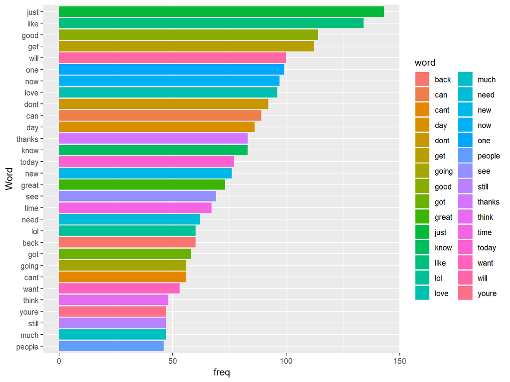

```r
tweet_freq = tweet_freq[order(-tweet_freq$freq),]
ggplot(data = head(tweet_freq,30), aes(x= reorder(word,freq),y=freq,fill = word)) +
  geom_bar(stat = "identity") +
  xlab("Word") +
  coord_flip()
```

### Nube de Palabras

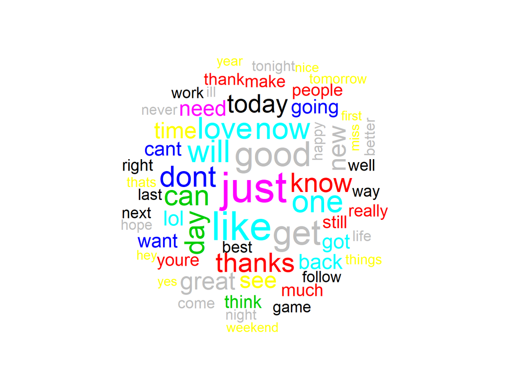

```r
wordcloud(tweet_freq$word,tweet_freq$freq,min.freq=30, random.color = F, max.words = 100,colors = 1:30, random.order = F)
```

## Blogs

### Top 10

```r
head(blog_freq,10)
```

|  | word | freq |
| --- | --- | --- |
| one | one | 134 |
| will | will | 107 |
| like | like | 102 |
| just | just | 99 |
| can | can | 94 |
| time | time | 86 |
| get | get | 72 |
| also | also | 71 |
| know | know | 68 |
| love | love | 63 |

### Histograma de Palabras

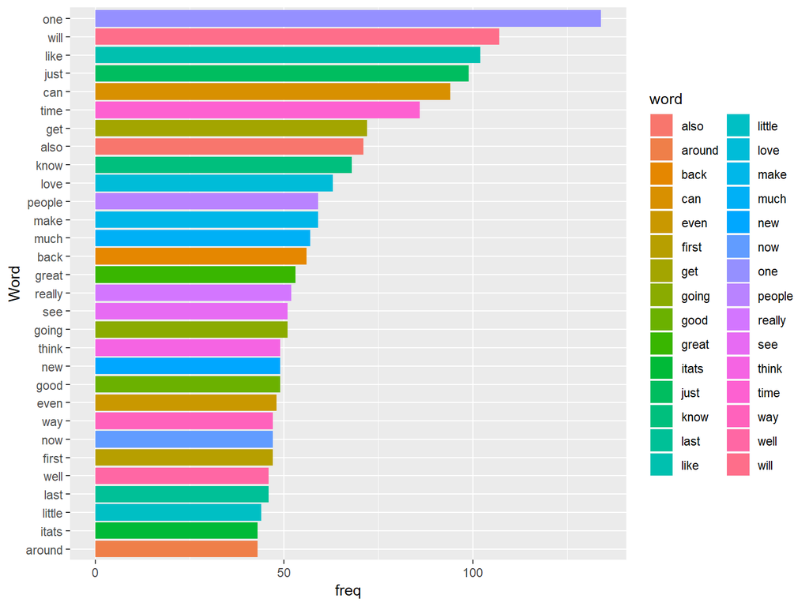

```r
blog_freq = blog_freq[order(-blog_freq$freq),]
ggplot(data = head(blog_freq,30), aes(x= reorder(word,freq),y=freq,fill = word)) +
  geom_bar(stat = "identity") +
  xlab("Word") +
  coord_flip()
```

### Nube de palabras

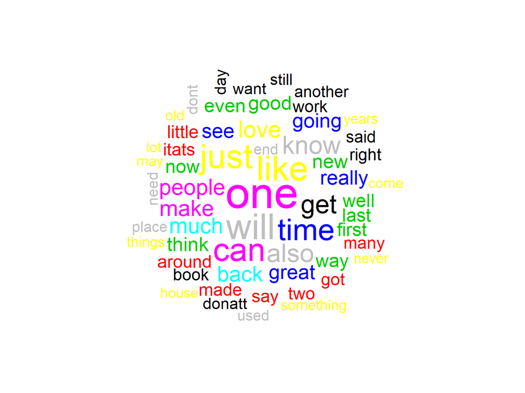

```r
wordcloud(blog_freq$word,blog_freq$freq,min.freq=30, random.color = F, max.words = 100,colors = 1:30, random.order = F)
```

## News

### Top 10

```r
head(news_freq,10)
```

|  | word | freq |
| --- | --- | --- |
| said | said | 224 |
| will | will | 90 |
| one | one | 79 |
| new | new | 69 |
| two | two | 67 |
| can | can | 67 |
| state | state | 64 |
| just | just | 61 |
| years | years | 58 |
| also | also | 56 |

### Histograma de Palabras

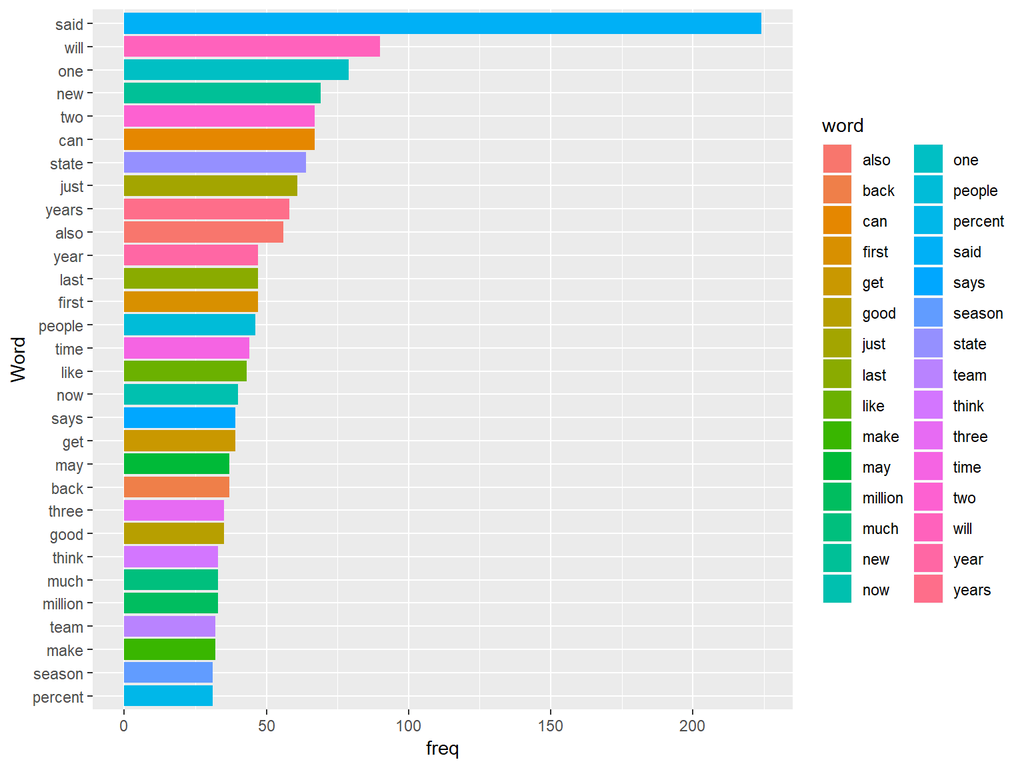

```r
news_freq = news_freq[order(-news_freq$freq),]
ggplot(data = head(news_freq,30), aes(x= reorder(word,freq),y=freq,fill = word)) +
  geom_bar(stat = "identity") +
  xlab("Word") +
  coord_flip()
```

### Nube de Palabras

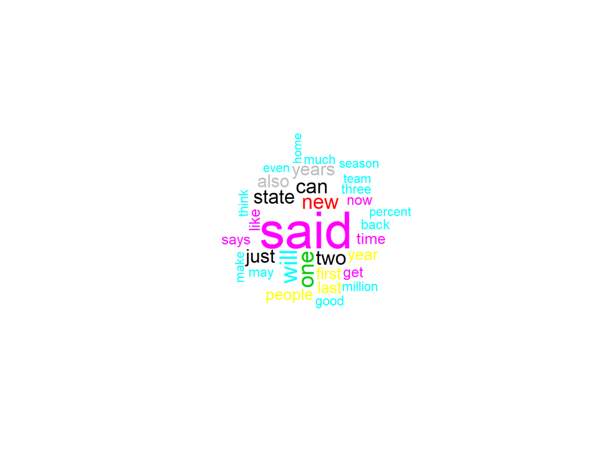

```r
wordcloud(news_freq$word,news_freq$freq,min.freq=30, random.color = F, max.words = 100,colors = 1:30, random.order = F)
```

## Discusion

La palabra mas repetida en el archivo Twitter fue “just”; en Blogs, “one”; y en News, “said”.

Las palabras más repetidas y que se encontraban en los tres archivos fueron: “just”, “will”, “one” y “can”.

# Calculo de probabilidades

Utilizamos un 0.1% de los todos los datos, por limitaciones de memoria.

```r
set.seed(123)

twittertxt = readLines("data/en_US.twitter.txt",skipNul = TRUE)
blogtxt = readLines("data/en_US.blogs.txt", skipNul = TRUE)
newscon = file("data/en_US.news.txt", 'rb')

newstxt = readLines(newscon)

twitter_txt = iconv(twittertxt, to="ASCII//TRANSLIT")
blog_txt = iconv(blogtxt, to="ASCII//TRANSLIT")
news_txt = iconv(newstxt, to="ASCII//TRANSLIT")


# partir los textos
tweets_sample <- sample(twitter_txt, round(2360148*0.001))
blogs_sample <- sample(blog_txt, round(899288*0.001))
news_sample <- sample(news_txt, round(1010242*0.001))


all_sample <- c(tweets_sample, blogs_sample, news_sample)

all_sample <- VCorpus(VectorSource(all_sample))

rm(twittertxt)
rm(twitter_txt)
rm(blogtxt)
rm(blog_txt)
rm(newscon)
rm(newstxt)
rm(news_txt)
rm(tweets_sample)
rm(blogs_sample)
rm(news_sample)

# lleva a minÃºsculas
all_sample <- tm_map(all_sample, content_transformer(tolower))

# quita espacios en blanco
all_sample <- tm_map(all_sample, content_transformer(stripWhitespace))

# remueve la puntuaciÃ³n
all_sample <- tm_map(all_sample, content_transformer(removePunctuation))

# remueve palabras vacias genericas
all_sample <- tm_map(all_sample, content_transformer(removeWords), c(stopwords("english")))

#remueve los numeros
all_sample <- tm_map(all_sample, content_transformer(removeNumbers))


## Unigramas

# crea matriz de terminos
tdm <- TermDocumentMatrix(all_sample)
#findFreqTerms(tweet_tdm, lowfreq=30)

## Dataframe de frecuencias
m <- as.matrix(tdm)

v <- sort(rowSums(m),decreasing=TRUE)

uni_freq <- data.frame(word = names(v),freq=v) %>%
  mutate(prob= (freq/sum(freq)))


#Funciones para hacer bi y trigramas

BigramTokenizer <- function(x) {RWeka::NGramTokenizer(x, RWeka::Weka_control(min=2, max=2))}
ThreegramTokenizer <- function(x) {RWeka::NGramTokenizer(x, RWeka::Weka_control(min=3, max=3))}


## Bigramas

bigram <- TermDocumentMatrix(all_sample, control = list(tokenize = BigramTokenizer))


m <- as.matrix(bigram)
v <- sort(rowSums(m),decreasing=TRUE)

bigram_freq <- data.frame(word = names(v),freq=v) %>%
  mutate(prob= (freq/sum(freq))) %>%
  separate(word, c("unigram", "predicted"), " ")

## Trigramas

trigram <- TermDocumentMatrix(all_sample, control = list(tokenize = ThreegramTokenizer))

m <- as.matrix(trigram)
v <- sort(rowSums(m),decreasing=TRUE)

trigram_freq <- data.frame(word = names(v),freq=v) %>%
  mutate(prob = (freq/sum(freq))) %>%
  separate(word, c("unigram1","unigram2", "predicted"), " ") %>%
  mutate(bigram = paste0(unigram1, " ", unigram2)) %>%
  select(bigram, everything()) %>%
  select(-c(unigram1, unigram2))

rm(list=c('all_sample', 'bigram', 'm', 'tdm', 'trigram'))
```

# Funcion predictora

La funcion puede iniciar con una sola palabra o una frase. En cualquier caso, toma en cuenta la última o las últimas dos palabras de la frase predice la siguiente palabra

```r
predictor <- function(phrase, bi_freq, tri_freq) {
  words <- strsplit(phrase, " ")[[1]]
  if (length(words) > 1) {
    bigram_to_predict <- tail(words, n = 2)
    tri_df <- tri_freq %>%
      filter(bigram == paste0(bigram_to_predict[1], " ", bigram_to_predict[2])) %>%
      arrange(desc(prob))
    return(tri_df[1,]$predicted)
  }

  else if (length(words == 1)) {
    bi_df <- bi_freq %>%
      filter(unigram == words) %>%
      arrange(desc(prob))
    return(bi_df[1,]$predicted)
  }
}
```

# Funcion predictora de las proximas tres palabras

Sencillamente utiliza la funcion anterior para devolver las siguientes tres palabras predichas.

```r
next_three <- function(phrase, bi_freq, tri_freq) {
  w1 <- predictor(phrase, bi_freq, tri_freq)
  w2 <- predictor(paste0(phrase, " ", w1), bi_freq, tri_freq)
  w3 <- predictor(paste0(phrase, " ", w1, " ", w2), bi_freq, tri_freq)
  return(c(w1, w2, w3))
}
```

# Predictor de palabras

Como ejemplo, se presentan los siguientes casos:

Una palabra: “can’t”

```r
temp <- next_three("cant", bigram_freq, trigram_freq)
print(paste(temp[1], " ", temp[2], " ", temp[3]))
```

```
## [1] "wait   see   ai"
```

En este caso, se predicen las palabras “wait”, “see” y “ai”.

Una palabra: “see”

```r
temp <- next_three("see", bigram_freq, trigram_freq)
print(paste(temp[1], " ", temp[2], " ", temp[3]))
```

```
## [1] "u   boo   NA"
```

En este caso, se predicen las palabras “u”, “boo” y no fue capaz de determinar una tercera palabra.

Dos palabras: “like one”

```r
temp <- next_three("like one", bigram_freq, trigram_freq)
print(paste(temp[1], " ", temp[2], " ", temp[3]))
```

```
## [1] "expect   much   greater"
```

En este caso, se predicen las palabras “expect”, “much” y “greater”.

Dos palabras: “random stuff”

```r
temp <- next_three("random stuff", bigram_freq, trigram_freq)
print(paste(temp[1], " ", temp[2], " ", temp[3]))
```

```
## [1] "makes   angry   NA"
```

En este caso, se predicen las palabras “makes”, “angry” y no fue capaz de determinar una tercera palabra.

Una frase: “i dont like this homework time”

```r
temp <- next_three("i dont like this homework time", bigram_freq, trigram_freq)
print(paste(temp[1], " ", temp[2], " ", temp[3]))
```

```
## [1] "joshuas   world   war"
```

En este caso, se predicen las palabras “joshuas”, “world” y “war”.

Una frase: “aint nobody got”

```r
temp <- next_three("aint nobody got", bigram_freq, trigram_freq)
print(paste(temp[1], " ", temp[2], " ", temp[3]))
```

```
## [1] "NA   NA   NA"
```

En este caso, desgraciadamente, no se predice nada.